# ***REMOVED*** Phosphoproteomic Analysis

Brett Engelmann(Integrative Proteomics)

February 7th, 2019

# Overview

T cells derived from ***REMOVED*** kinase dead (D137N mutation within HRD motif) and wild type mice were *ex vivo* stiumlated with H_2O_2 or CD3/CD28 at specific time points. The goal of this project is to assess changes in phosphoproteomic profiles due to treatment and/or strain.

[figure not shown]

Shannon1

Note that a time dependent phenotypic change in cell adhesion was observed.

[figure not shown]

Shannon2

The data were processed with maxquant/andromeda (V 1.6.0.16) on 1/14/19 using the mouse database `Mus_musculus.GRCm38.95.pep.all.parsedCCDS.fa` retrieved from Ensembl on the same day.32956 translated transcripts with CCDS identifiers are present in this FASTA file. A common contaminants list was appended to this `FASTA` to facilitate their exclusion. The mq parameters file `mqpar1_14_19` in this directory has all the MQ parameter choices.

Some key MaxQuant processing parameters:

- FixedMod = Carbamidomethyl
- VarMod = Oxidation(M); Acetyl (Protein N-term); Phospho (STY) (for appropriate samples)
- PSM/Protein/Site FDR = .01 using reverted database as decoys
- The match-between-runs (MBR) feature was enabled
- Label free quantification (MQ-LFQ) on XICs was employed

Below I analyze the data from the project. Specifically, I assess coverage and quality, transform and normalize the data, perform EDA, impute, and batch effect correct the data. Then, I construct the proper statistical models for differential phosphorylation analysis. Then, I perform a series of enrichment analyses on the data using appropriate ontologies. Finally, the results are exported in a format suitable for web-application deployment.

# Phosphoproteome Coverage

80.3% of the identified peptides were phosphorylated.

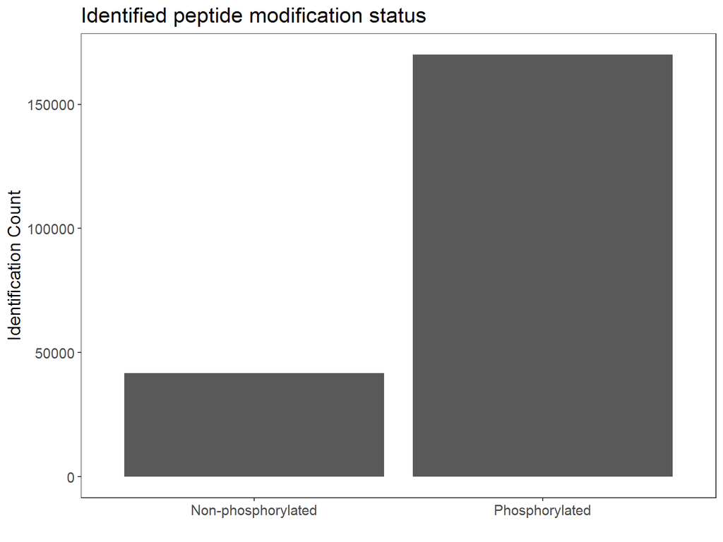

# Phosphopeptide QC stats

Mass error by intensity, AA breakdown, and phosphopeptide “multiplicity” (phosphopeptide phosphorylation count) pie and venn diagram overlay by site (AA position within the protein).

Average mass error is 0.0389473 parts per milllion. There is no strong relationship between intensity and mass error.

[figure not shown]

Breakdown of phosphosites by AA and multiplicity is as expected

[figure not shown]

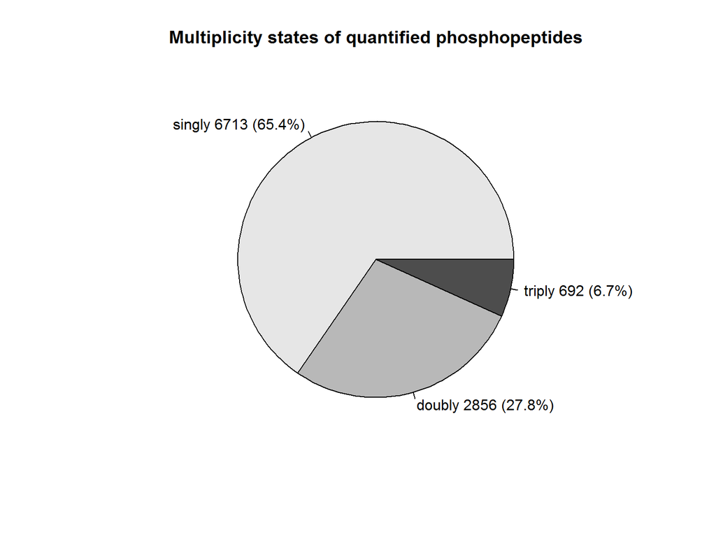

Most phosphosites are observed as singletons.

[figure not shown]

# Identification and quantification

MQ outputs a `Phospho (STY)Sites` summary table that gives all *sites* within a protein that are identified. Singly, doubly, and triply phosphorylated peptides that map/localize to this site are quantified. Class 1 sites are sites with median localiztion probability ~.95 and minimum localization probability of .75.

12483 sites were identified in at least one sample at an FDR of 1%. A breakdown of phoshposites by identification, quantification, and localization probability:

[figure not shown]

# Exploratory Data Analysis

## Boxplots & Heatmaps

7018 class 1 quantified phowphopeptides were identified in at least one sample and 442 were quantified in all samples. Log2 transform XIC Intensity values for the 24 samples. Boxplot and and pearson correlation of replicate experiments are shown below.

[figure not shown]

[interactive chart not shown]

Here are the spearman plots for the raw values.

[interactive chart not shown]

The data are median and quantile normalized.

The pairwise correlations are roughly the same following normalization.

Spearman

[interactive chart not shown]

Pearson

[interactive chart not shown]

[figure not shown]

## Principal Components Analysis

```
## [1] TRUE
```

Here I explore variance of median & quantile normalized phosphopeptides. *This data frame is derived from measurements observed in all samples*. This plot below is calculated with **ONLY** 442 phosphopeptides. A dominant rationalizable variance ‘signature’ in this dataset is treatment followed by time.

[figure not shown]

# Imputation

7018 phosphopeptides were measred in at least one. **Only 442 are truly observed in each of the samples**. Here I will impute across all samples. Imputation is cached here because I cannot manually set the random number seed.

```
## Cluster size 6966 broken into 819 6147
## Done cluster 819
## Cluster size 6147 broken into 843 5304
## Done cluster 843
## Cluster size 5304 broken into 2775 2529
## Cluster size 2775 broken into 742 2033
## Done cluster 742
## Cluster size 2033 broken into 435 1598
## Done cluster 435
## Cluster size 1598 broken into 1376 222
## Done cluster 1376
## Done cluster 222
## Done cluster 1598
## Done cluster 2033
## Done cluster 2775
## Cluster size 2529 broken into 1180 1349
## Done cluster 1180
## Done cluster 1349
## Done cluster 2529
## Done cluster 5304
## Done cluster 6147
```

## PCA of imputed data across all samples

[figure not shown]

# Model Definitions

We would like to identify differentially phosphorylated peptides between or across: 1) Strains 2) Treatments 3) Times

> “All models are wrong but some are useful” - George Box

Model 1 only includes zeros and treatments at time 5 min to test for differential phosphorylation across strains and treatments. This model will include an interaction effect whose coefficients will test for treatment specific strain differences at a single time point (5 or 0 minutes).

Model 2 is a generalized additive model (GAM) that uses data normalized to strain specific 0s will be used to test for differences at any point in time within and across each strain in response to CD3/CD28 costimultaion. The first model, although it does not use all the data, benefits from the other data at the normalization and imputation steps. The second model, although it loses degrees of freedom by standardizing to zero removes the issue of confounding between time 0 and ‘untreated’. Separate heuristics will be applied to each model in order to ensure all suitable data is applied.

## Model I - Differences Due to Treatment and/or Strain

Linear regression model with surrogate variables (see below) added as covariates:

$$Y_{ijk} = Treat_i + Strain_j + Treat_i*Strain_j + SV_l + {\epsilon}_{ijk}: i = none,CD3/CD28,H_2O_2; j=WT,Mutant; k = 1,...,16; l=1,...,N$$
where $Y_{ijk}$ is logged phosphosite intensity of culture replicate k from strain j treatment i. $Treat_i$ is the estimated effect from treatment i, $Strain_j$ is the estimated effect from strain j and the interaction term is the estimated effect of treatment specific strain effects. $SV_k$ is the estimated effect from a covariate ‘surrogate variable’ l identified from the data.

### Heuristic I

For model I a phosphopeptide needs to be observed in either:

1. at least half of the biological replicates for each treatment (for more confident imputation: an anchor in every treatment)
2. all of the biological replicates for any single treatment (for new phosphopeptides unique to a single treatment)
3. at least half of the biological replicates for each strain (for more confident imputation: an anchor in every strain)
4. all of the biological replicates for any single strain (for new phosphopeptides unique to a single strain)

**4163** phosphopeptides satisfy any of the above conditions. The `ts.frame.passed` and `ts.frame.binary.passed` data frames are used for modeling. The binary data frame has the logical results of the heuristic test associated with each peptide. The peptides that do not pass the test have been removed.

## Model II - Differences Due to Treatment

For each strain a time zero estimate is calculated. The data are normalized to the strain specific zero time point. A generalized additive model is fit with a natural cubic spline smoothing function which captures nonlinear temporal phosphosite profiles. More specifically,

$$Y_{ijk} = Strain_j + Strain_j*S(Time_k) + {\epsilon}_{ijk}: i = 1,...,12; j=WT,***REMOVED***; k=5,20,60$$

where $Y_{ijk}$ is logged phosphosite intensity of culture replicate i from strain j at time k. $Strain_j$ is the estimated average effect from strain j, $S(Time_k)$ is a smoothing function that will capture effects of time on phosphopeptide intensity levels. The smoothing function used is a natural cubic spline, that is the second derivative = 0 at the boundary knots. A single knot is automatically chosen at the 50th quantile of the data (20 min here). boundary knots are at 0 and 60 min. The interaction term is the estimated effect of strain specific timecourse profiles.

### Heuristic II

Due to sample processing issues, a few donors have missing samples. For the timecourse, a phosphopeptide is considered if it has **either**:

1. at least 3 observations in each strain (half of the samples for each strain)
2. all times (not samples) observed in either strain

1 ensures that we are using imputation results grounded by real measurements and 2 ensures we are not throwing away sites that turn on/off in specific strains (largest postentially most significant findings)

**3256** phosphopeptides satisfy either 1 or 2 from heuristic II. The `MedianQuantiledImputedCentered.passed` and `MedianQuantiledImputedCentered.binary.passed` data frames are used for modeling. The binary data frame has the logical results of the heuristic II test associated with each peptide. The peptides that do not pass the test have been removed.

# Latent variation correction with SVA

Here I attempt to correct for unwanted latent sources of variation with **surrogate variable analysis (SVA)**, a popular form of weighted factor analysis. For the first model I have protected treatment and strain and for the second model I have protected the effects of time and strain using a generalized additive model (see section above for more details on each model).

## Model I

Here I work with the `ts.frame.passed` dataframe to identifiy factors not associated with strain or stimulation.

```
## [1] TRUE
```

```
## Number of significant surrogate variables is:  3
## Iteration (out of 5 ):1  2  3  4  5
```

3 surrogate variables were identified. Below are the PCA plots before and after regressing away the surrogate variables. Both before and after surrogate variable regression, the samples cluster together most prominantly by stimulation.

[figure not shown]

## Model II

Here I work with the `MedianQuantiledImputedCentered.passed` dataframe to identifiy factors not associated with strain or time within the GAM outlined above.

```
## [1] TRUE
```

```
## [1] TRUE
```

```
## Number of significant surrogate variables is:  2
## Iteration (out of 5 ):1  2  3  4  5
```

2 surrogate variables were identified from the centered data. Below are the PCA plots before and after regressing away the surrogate variables. In both cases, PC1 separates samples by time and PC2 separates by strain.

[figure not shown]

# Inference

Differential phosphorylation is performed with the `limma` framework for both models.

## Model I

**4163** phosphopeptides were ultimately fit to the interaction model (see Model Definitions above). The three SVs identified above were included as covariates.

```
## [1] TRUE
```

A few EDA plots show no obvious artifacts associated with this analysis.

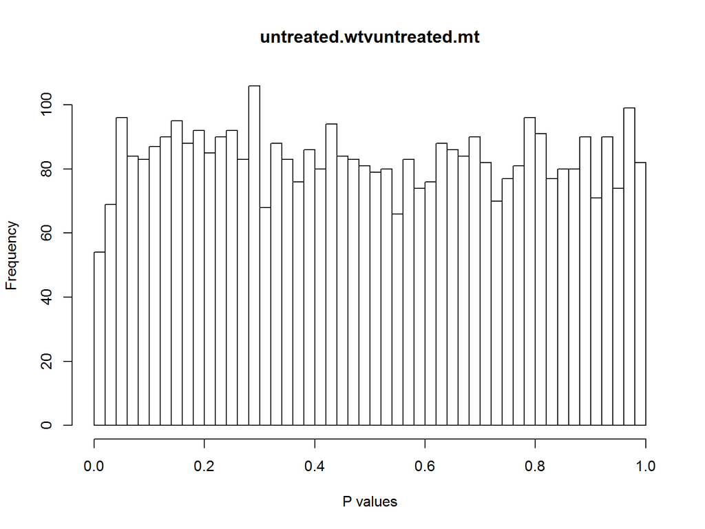

[figure not shown]

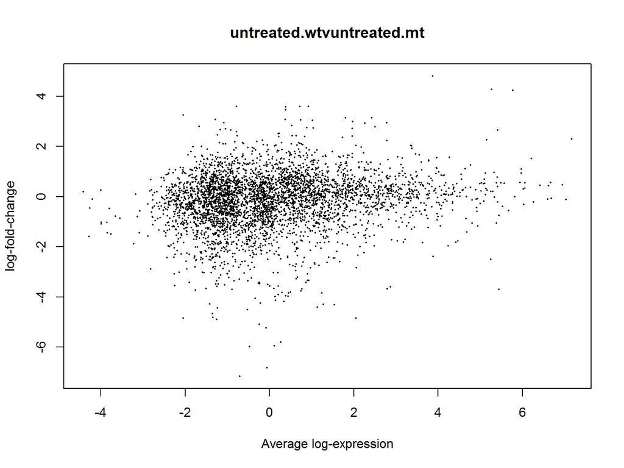

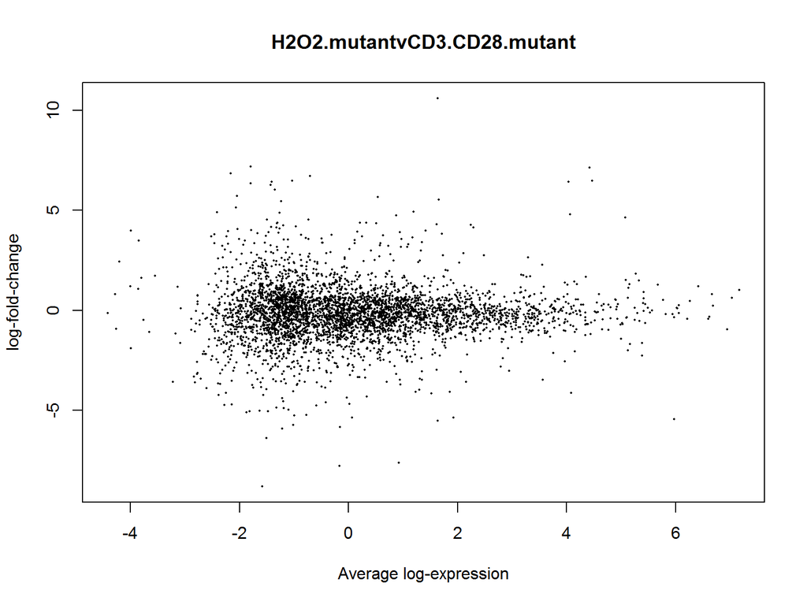

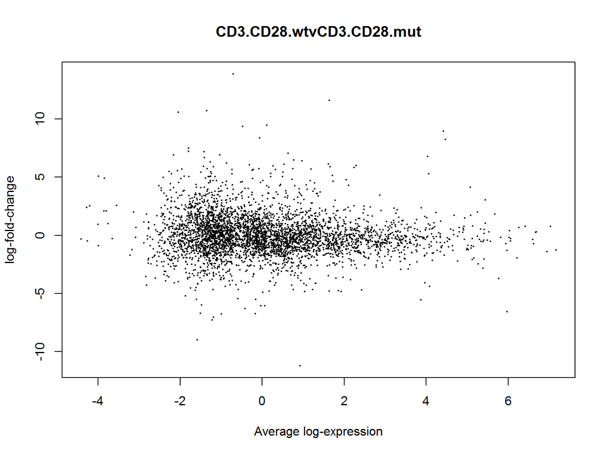

[figure not shown]

### Example plot

Below is the peptide with the lowest p-value testing the null hypothesis that there is no difference in phosphosite levels between CD3.CD28.wt samples and CD3.CD28.mut samples. Here `idmult = 6173_1` is used with the `SV.regressed.modelI` and `ts.frame.binary.passed` data frames. Two different faceting approaches are applied.

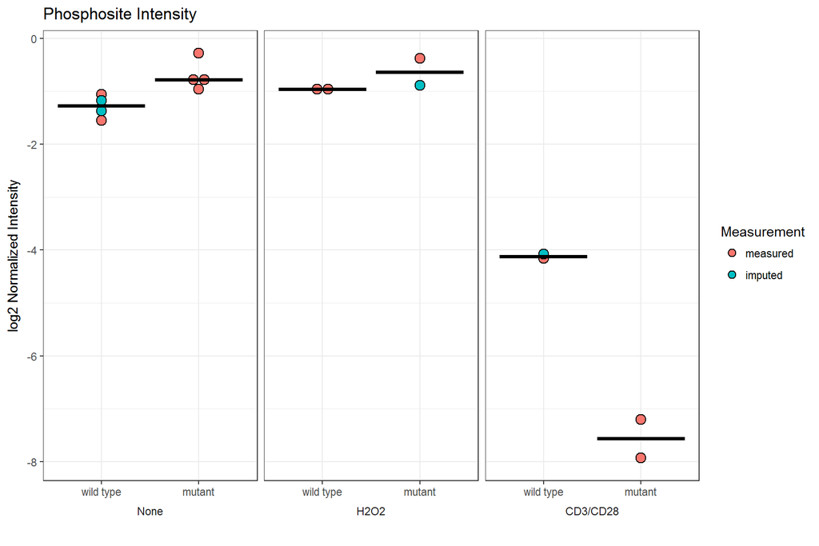

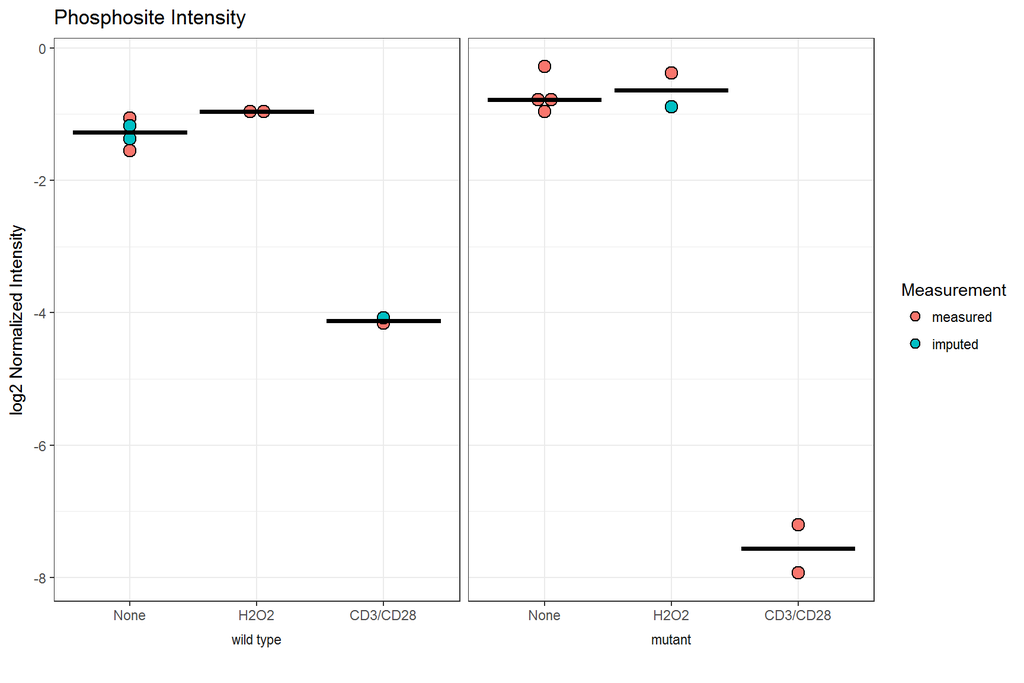

## Model II

A natural cubic spline was fit to each CD3/CD28 stimulated timecourse. I used the SV regressed data frame containing **3256** phosphopeptides that passed the heuristics for model II outlined above.

Three types of tests were performed:

1. Differential phosphorylation across strains at any time
2. A significant change in phosphorylation due to time
3. A change in the time effect across strains (interaction)

### Spline plot examples

The top hit `idmult 7072_2` for within-strain mutant time effect is plotted below. Here I used with the `SV.regressed.modelII` and `meta.data.centered` data frames.

[figure not shown]

# Enrichment Analysis

Enrichments on PhosphoSitePlus kinase substrate information as well as reactome and go (bp,mf,cc, slim). Each annotation is represented at least three times in the dataset to be considered.

# Data Export

Exported:

1. The median, quantile normalized, imputed (across all samples) and SV regressed, phosphopeptide XICs for models I and II
2. The MS meta data and other identifiers associated with each site
3. A binary matrix indicating if a data point was measured (1) or imputed (0) for models I and II
4. Study meta data
5. Results from inferences tests from models I and II
6. Results of all enrichment analyses

Numbers 1 and 2 are combined into a single table `SiteTableCombined`. Note that the `SiteTableCombined` table has a ‘dupidmult’ column for duplicated quantifications that account for doubly or triply phosphorylated peptides mapping to mulitple sites. Numbers 3 and 4 are single tables. 4 may or may not be available.

**note that multiply phosphorylated peptides are only represented once and therefore in such cases the site of modification is not unique**

The key for annotation mergining is the ENSMUSP identifier in the ‘protein’ column. MGI symbols that map to protein ENSMUSPs are sourced from biomart ensembl94 database. **note that some proteins do not have MGI symbols mapped**